# Lab 1: From observations to networks

Peter McMahan for [SOCI 424](https://soci424.netlify.app/)

## 1b.

> > Is there anything you can tell informally about the social structure among these women just by looking at the events table? Do you think the women are separated into different cliques? Do you think some of the people might be more central to the social life than others?

> While it’s hard to say anything substatial, it does look like there are two major “clusters” of women who tended to participate in the same events. Moreover, there are clearly some women who participate in many more evens than others, suggesting they may be more central to the social scene.

## 1c.

> > One way to represent data of this type in R is as a matrix with values `1` (representing participation) and `0` (representing non-participation). The following snippet creates such a matrix, with 18 rows and 14 columns. However, it is missing data for Miss Charlotte McDowd, Miss Ruth Desand, and Mrs. Flora Price, who are erroneously indicated to have not participated in any events. *Using the figure above, update the code below to include participation for these three women.* (You can copy and paste the code into your own file in RStudio and edit it there)

> The completed `matrix()` command looks like this:

> ```r
> events <- matrix(c(
>   1,1,1,1,1,1,0,1,1,0,0,0,0,0,
>   1,1,1,0,1,1,1,1,0,0,0,0,0,0,
>   0,1,1,1,1,1,1,1,1,0,0,0,0,0,
>   1,0,1,1,1,1,1,1,0,0,0,0,0,0,
>   0,0,1,1,1,0,1,0,0,0,0,0,0,0,
>   0,0,1,0,1,1,0,1,0,0,0,0,0,0,
>   0,0,0,0,1,1,1,1,0,0,0,0,0,0,
>   0,0,0,0,0,1,0,1,1,0,0,0,0,0,
>   0,0,0,0,1,0,1,1,1,0,0,0,0,0,
>   0,0,0,0,0,0,1,1,1,0,0,1,0,0,
>   0,0,0,0,0,0,0,1,1,1,0,1,0,0,
>   0,0,0,0,0,0,0,1,1,1,0,1,1,1,
>   0,0,0,0,0,0,1,1,1,1,0,1,1,1,
>   0,0,0,0,0,1,1,0,1,1,1,1,1,1,
>   0,0,0,0,0,0,1,1,0,1,1,1,1,1,
>   0,0,0,0,0,0,0,1,1,1,0,1,0,0,
>   0,0,0,0,0,0,0,0,1,0,1,0,0,0,
>   0,0,0,0,0,0,0,0,1,0,1,0,0,0
> ), nrow=18, byrow=TRUE)
> ```

## 1d.

> > Now that the table is represented in the matrix `events`, we can use R to tell us a bit more about it. The functions `rowSums(events)` and `colSums(events)` will add up all of the numbers in each row and in each column of `events`, respectively. Using these functions, answer the following questions (*show your code for each*):
> > - Which event was the most popular (had the most attendees)?
> > - How many women attended exactly four events? To find the most-attended event, you can examine the *column* sums directly:

> ```r
> colSums(events)
> ```

> ```
> ##  [1]  3  3  6  4  8  8 10 14 12  6  4  7  4  4
> ```

> ```r
> event_participation <- colSums(events)
> which.max(event_participation)
> ```

> ```
> ## [1] 8
> ```

> To find how many events were attended by exactly, you can examine the *row* sums directly:

> ```r
> rowSums(events)
> ```

> ```
> ##  [1] 8 7 8 7 4 4 4 3 4 4 4 6 7 8 7 4 2 2
> ```

> From this you can count that seven of the women attended exactly 4 events. But you can also have R do this counting for you:

> ```r
> person_participation <- rowSums(events)
> # create a vector with TRUE for women who attended exactly four events:
> attended_four <- person_participation==4
> attended_four
> ```

> ```
> ##  [1] FALSE FALSE FALSE FALSE  TRUE  TRUE  TRUE FALSE  TRUE  TRUE  TRUE FALSE
> ## [13] FALSE FALSE FALSE  TRUE FALSE FALSE
> ```

> ```r
> # when you take the `sum()` of a TRUE/FALSE vector, it simply counts the
> # number of TRUE values:
> sum(attended_four)
> ```

> ```
> ## [1] 7
> ```

## 2a.

> > Fortunately for us, there is a very basic technique from linear algebra that will turn an *affiliation matrix* like the one you created above into a *co-occurrence* matrix that will measure co-attendance at events. To do so, we will use matrix multiplication. You don’t need to know anything about linear algebra for this to work, and for the time being, you can just treat it like a magic wand (we will cover this more in a later class).

> ```r
> co_attend <- events %*% t(events)
> ```

## 2b.

> > Visually inspect this new matrix `co_attend`, either by typing it into the R console on its own or by clicking on it in the RStudio “environment” pane.
> > - How many rows and columns does it have?

> `co_attend` had 18 rows and 18 columns

> ```r
> dim(co_attend)
> ```

> ```
> ## [1] 18 18
> ```

> > - What number is in the third row of the first column, and what does it represent in plain language?

> The number in the third row of the first column represents the number of events that Miss Theresa Anderson attended with Mrs. Evelyn Jefferson:

> ```r
> co_attend[3,1]
> ```

> ```
> ## [1] 7
> ```

> > - What number is in the last row of the last column, and what does it represent in plain language?

> The number in the last row of the last column represents the total number of events that Mrs. Flora Price attended:

> ```r
> co_attend[18,18]
> ```

> ```
> ## [1] 2
> ```

> > - Where would you look in this matrix to tell how many events Mrs. Flora Price co-attended with Miss Laura Mandeville?

> To find that out, you could look either in the last row of the second column (`co_attend[18,2]`) *or* the second row of the last column (`co_attend[2,18]`). The value is 0.

## 2c.

> > Use the `max()` and `min()` functions to determine the maximum and minimum number of events that any pair of women in this sample attended together. *Note: this question was harder than I intended! To get the right answer you need to exclude the diagonal of the matrix.* One way to do do this is to look only at the ‘upper triangular’ part of the matrix:

> ```r
> # get the values from just the upper triangular part
> co_attend_utri <- co_attend[upper.tri(co_attend)]
> # print it
> co_attend_utri
> ```

> ```
> ##   [1] 6 7 6 6 6 6 3 3 4 4 4 4 4 4 2 3 4 4 4 2 3 3 2 3 2 0 2 2 3 3 4 3 2 2 3 2 2
> ##  [38] 2 3 2 1 1 2 2 3 2 1 2 1 0 1 1 2 2 3 2 1 2 1 0 1 1 2 2 3 4 2 2 3 2 1 1 2 2
> ##  [75] 3 4 4 6 2 2 3 2 1 1 2 2 2 3 3 5 6 1 2 2 2 1 1 2 1 2 3 3 5 6 6 2 1 2 1 0 1
> ## [112] 1 2 2 3 4 4 4 3 3 1 0 1 0 0 0 0 1 1 1 1 1 1 2 1 1 1 0 1 0 0 0 0 1 1 1 1 1
> ## [149] 1 2 1 1 2
> ```

> ```r
> # what's the max?
> max(co_attend_utri)
> ```

> ```
> ## [1] 7
> ```

> ```r
> # and the min?
> min(co_attend_utri)
> ```

> ```
> ## [1] 0
> ```

## 2d.

> > Make a new matrix, called `co_attend_3plus` that has the same shape as `co_attend`, but whose values are either `TRUE` or `FALSE`, indicating for each pair of women whether they have attended *at least 3* event together. (*Note: This one may be a little tricky for new R users. The operator `>=` will tell you whether the value on the left is at least as big as the value on the right.*)

> ```r
> co_attend_3plus <- co_attend >= 3
> ```

> > - How does `co_attend_3plus` represent a different type of relationship between the pairs of women than `co_attend`?

> `co_attend` represents the *number* of events each pair of women attendended together. This represents a relation of social connection that ranges from non-existent (0) to weak (1) to strong (7). In contrast, `co_attend_3plus` represents a binary (0/1) relation of relatively strong social connections.

## 3a.

> > The function `graph_from_adjacency_matrix()` from the `igraph` package converts an *adjacency matrix* like the co-attendance matrix you created above into a `graph` object. It automatically figures out how many nodes there are in the network by looking at the number of rows/columns in the matrix, and constructs edges between those nodes based on the data. Use the following command to created an *undirected*, *weighted* network from the `co_attend` matrix you already made:

> ```r
> library(igraph)
> event_net <- graph_from_adjacency_matrix(
>   co_attend, mode='undirected',
>   weighted=TRUE, diag=FALSE)
> ```

## 3b.

> > We will talk about plotting networks in detail later in the course, but for the moment we can mostly use the default options built into `igraph`. Use the following two commands to (a) tell `igraph` that we want the weight of the edges to be reflected in the width of the lines in the plot, and (b) to plot `event_net` using the default parameters. Don’t worry about how these commands work yet.

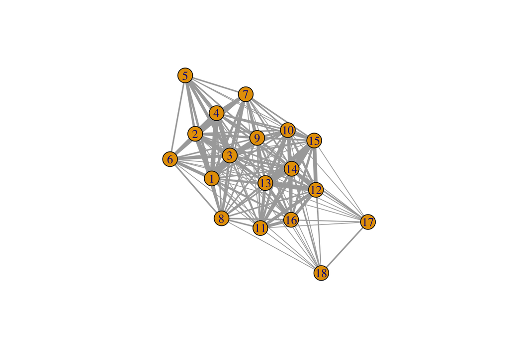

> ```r
> E(event_net)$width <- E(event_net)$weight
> plot(event_net)
> ```

## 3c.

> > Look at the plot that is created. What kinds of patterns can you see? Who is central and who is peripheral to the social structure this network represents?

> This is a tightly connected network. Some women seem central to the network (e.g. Miss Ruth DeSand, labeled 9 in the graph), while others have only a peripheral attachment (e.g. number 18, Miss Flora Price, who only has week connections to the other nodes).

## 3d.

> > We are now going to create and plot an *unweighted* network from the matrix `co_attend_3plus` you created earlier based on a different measure of “relationship” between the women.

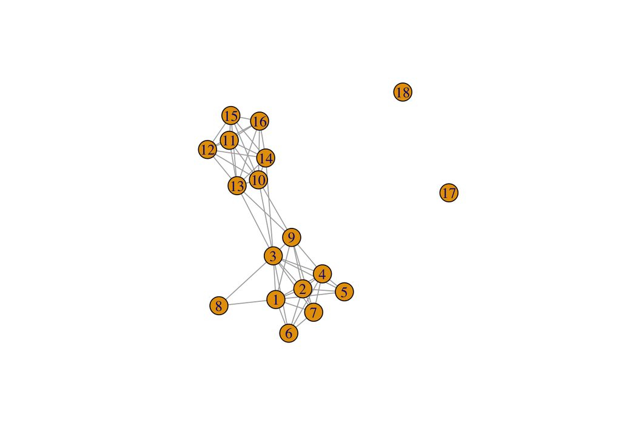

> ```r
> event_net_3plus <- graph_from_adjacency_matrix(
>  co_attend_3plus, mode='undirected', diag=FALSE)
> plot(event_net_3plus)
> ```

> > Execute the commands above and inspect this new network visually, then answer the following questions:
> > - What is different about this network?

> This network is *much* sparser. It also seems to show more obvious structure, with two small ‘clusters’. Moreover, there are now isolated nodes (17 and 18) that are not connected to anyone else in the network.
> > - Why does it look so different?

> By removing the weakest relations, the network shows only ties that represent a relatively strong link between the women. This means that we are hiding the co-attendance patters than might be incidental or accidental. This way, the clique structure of the network becomes more apparent.
> > - In what ways is this new network a better representation of the social structure among the women? In what ways is it worse?

> This new network is more likely to show the underlying social structure that these women are embedded in. However it makes certain women seem less connected than they actually are (e.g. is Miss Flora Price *really* completely isolated from the group, even having attended two events?). Moreover, the reduced network loses any sense of different strength of tie, so it erases the fact that, e.g., Mrs. Evelyn Jefferson is very tightly tied to Miss Theresa Anderson but less tightly tied to Miss Charlotte McDowd—both ties are coded simply as “present” in `event_net_3plus`.